# 9/5: Simple Libear Regression

```r
load("/Users/isabellelangrock/Desktop/Stats500/Rst500.RData")
library(ltm)
library(car)
```

# Thursday, September 5

## Simple Linear Regression - Chapter 2 in Sheather (Simon Sheather)

### *Living, Breathing, Plotting*

```r
fuel
```

```
##    ID state Fuel   Tax License   Inc   Road
## 1   1    ME  541  9.00    52.5 3.571  1.976
## 2   2    NH  524  9.00    57.2 4.092  1.250
## 3   3    VT  561  9.00    58.0 3.865  1.586
## 4   4    MA  414  7.50    52.9 4.870  2.351
## 5   5    RI  410  8.00    54.4 4.399  0.431
## 6   6    CN  457 10.00    57.1 5.342  1.333
## 7   7    NY  344  8.00    45.1 5.319 11.868
## 8   8    NJ  467  8.00    55.3 5.126  2.138
## 9   9    PA  464  8.00    52.9 4.447  8.577
## 10 10    OH  498  7.00    55.2 4.512  8.507
## 11 11    IN  580  8.00    53.0 4.391  5.939
## 12 12    IL  471  7.50    52.5 5.126 14.186
## 13 13    MI  525  7.00    57.4 4.817  6.930
## 14 14    WI  508  7.00    54.5 4.207  6.580
```

[output cut: 34 more lines]

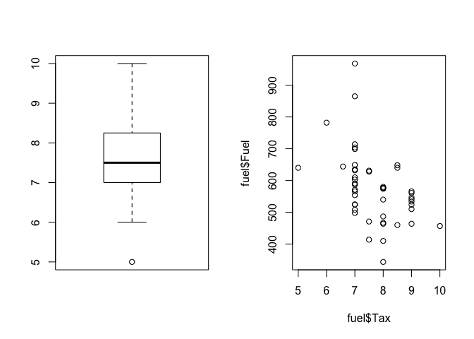

```r
par(mfrow=c(1,2))
boxplot(fuel$Tax)
plot(fuel$Tax,fuel$Fuel)
```

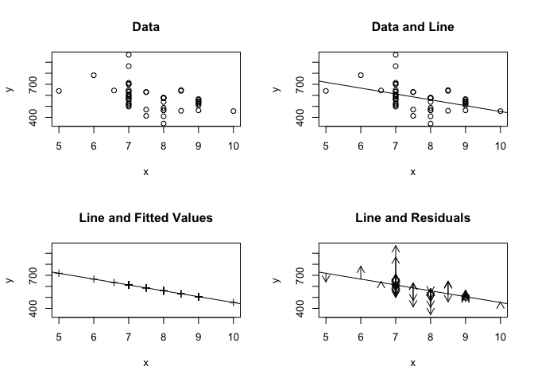

```r
arrowplot(fuel$Tax, fuel$Fuel)
```

```r
plot(fuel$Tax, fuel$Fuel)
abline(fuel$Tax, fuel$Fuel)
abline(lm(fuel$Fuel~fuel$Tax), col="red")
lm_sample <- lm(fuel$Fuel~fuel$Tax)
res<- lm_sample$residual
res
```

```
##           1           2           3           4           5           6
##   34.949053   17.949053   54.949053 -171.710393 -149.157245    4.055351
##           7           8           9          10          11          12
## -215.157245  -92.157245  -95.157245 -114.263542   20.842755 -114.710393
##          13          14          15          16          17          18
##  -87.263542 -104.263542  -46.263542   22.736458   -9.263542  101.736458
##          19          20          21          22          23          24
##  252.736458  107.395904   36.736458  -19.157245  -42.050947   40.949053
##          25          26          27          28          29          30
##  -72.604096   59.949053   17.842755   45.289607   14.842755   27.949053
##          31          32          33          34          35          36
##  -41.263542  -58.263542   17.842755   42.289607  -72.157245    9.431812
##          37          38          39          40          41          42
##  -78.476138   91.736458  115.395904  355.736458  -25.263542   86.736458
##          43          44          45          46          47          48
##   19.736458  -21.263542  116.630160    3.949053   -2.263542  -88.263542
```

```r
fit <- lm_sample$fitted
fit
```

```
##        1        2        3        4        5        6        7        8
## 506.0509 506.0509 506.0509 585.7104 559.1572 452.9446 559.1572 559.1572
##        9       10       11       12       13       14       15       16
## 559.1572 612.2635 559.1572 585.7104 612.2635 612.2635 612.2635 612.2635
##       17       18       19       20       21       22       23       24
## 612.2635 612.2635 612.2635 532.6041 612.2635 559.1572 506.0509 506.0509
##       25       26       27       28       29       30       31       32
## 532.6041 506.0509 559.1572 585.7104 559.1572 506.0509 612.2635 612.2635
##       33       34       35       36       37       38       39       40
## 559.1572 585.7104 559.1572 634.5682 718.4761 612.2635 532.6041 612.2635
##       41       42       43       44       45       46       47       48
## 612.2635 612.2635 612.2635 612.2635 665.3698 506.0509 612.2635 612.2635
```

```r
str(lm_sample)
```

[output not shown]

```r
cbind(fuel, fit, res)
```

```
##    ID state Fuel   Tax License   Inc   Road      fit         res
## 1   1    ME  541  9.00    52.5 3.571  1.976 506.0509   34.949053
## 2   2    NH  524  9.00    57.2 4.092  1.250 506.0509   17.949053
## 3   3    VT  561  9.00    58.0 3.865  1.586 506.0509   54.949053
## 4   4    MA  414  7.50    52.9 4.870  2.351 585.7104 -171.710393
## 5   5    RI  410  8.00    54.4 4.399  0.431 559.1572 -149.157245
## 6   6    CN  457 10.00    57.1 5.342  1.333 452.9446    4.055351
## 7   7    NY  344  8.00    45.1 5.319 11.868 559.1572 -215.157245
## 8   8    NJ  467  8.00    55.3 5.126  2.138 559.1572  -92.157245
## 9   9    PA  464  8.00    52.9 4.447  8.577 559.1572  -95.157245
## 10 10    OH  498  7.00    55.2 4.512  8.507 612.2635 -114.263542
## 11 11    IN  580  8.00    53.0 4.391  5.939 559.1572   20.842755
## 12 12    IL  471  7.50    52.5 5.126 14.186 585.7104 -114.710393
## 13 13    MI  525  7.00    57.4 4.817  6.930 612.2635  -87.263542
## 14 14    WI  508  7.00    54.5 4.207  6.580 612.2635 -104.263542
```

[output cut: 34 more lines]

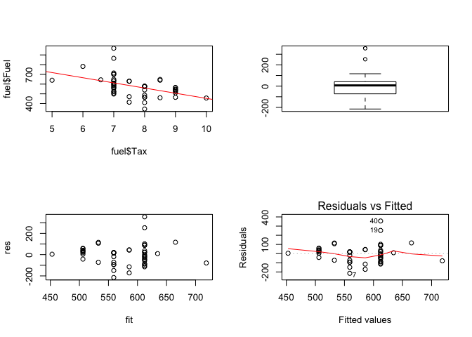

```r
boxplot(res)
plot(fit, res)
plot(lm_sample)
```

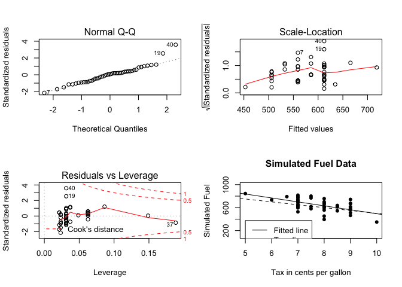

```r
fuelsim()
```

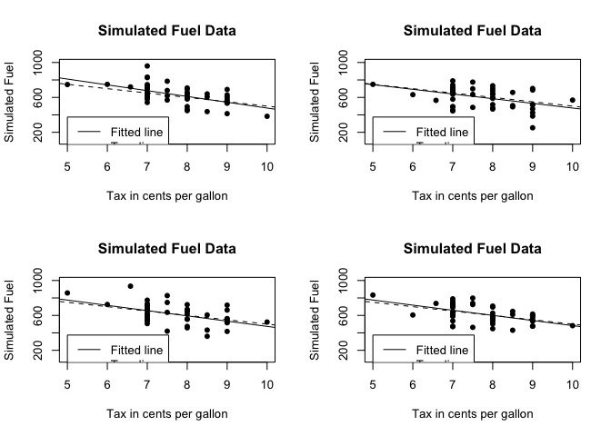

```r
par(mfrow=c(2,2))
fuelsim()
fuelsim()
fuelsim()
fuelsim()
```

```r
s<-fuelsimbeta(1000)
boxplot(s)
mean(s)
```

```
## [1] -49.38838
```

```r
sd(s)
```

```
## [1] 15.38789
```

[figure not shown]

$\alpha + \beta X_{1}$ is the fitted value for $\widehat{x}$ $y_{i} - \widehat{y_{i}} = y_{i}-(\widehat{\alpha}+\widehat{s}x_{i}) = R_{i}$ Want $R_{i}$ to be small Want $y_{i} - \widehat{y_{i}}$ to be small Total or mean residual: $\sum R_{i}$ Least Squares $\sum_{i=1}^n (y_{i} - \widehat{y_{i}})^2 = \sum_{i=1}^n R_i^2$

How do you do it? How do you find $\widehat{\alpha}$ and $\widehat{\beta}$

- you let the computer do it
- you do calculus
- formulas (“not that helpful”)
  - 1 X (pg. 19 in Sheather)
  - Many Xs -> matrix formulas
- You do something computationally stable

Least squares pays a lot of attention to every point, so outliers can have **big** effects.  
**fitted** values tell us what the linear model predicts and the **residuals** show the error between the expected and the actual values. We would like to see no obvious pattern in the residuals. The plot of fit x res should **NOT** be interesting, otherwise it indicates that you could find a much better model to fit the data.

$y_{i} = \alpha + \beta x_{i} + e_{i}$

$Fuel_{i} =\alpha + \beta TAX_{i} + e_{i}$

$e_{i}$ are independent, identically distributed, Normal with mean 0 and variance $\sigma^2$ or $e_{i}$ ~ $N(0,\sigma^2)$

General version: $(y_{1}-\widehat{y_{i}})^2 + (y_{2}-\widehat{y_{i}})^2 + ... + (y_{n}-\widehat{y_{i}})^2]/(sample size - Number of parameters for model)$